# Week of 2025.4.14

- Parse InSAR
- Parse AEM data
- Plot both as part of a 3D plot

## InSAR

```
<xarray.Dataset> Size: 397MB
Dimensions:  (x: 9289, y: 10676)
Coordinates:
  * x        (x) float64 74kB -124.5 -124.5 -124.5 ... -114.0 -114.0 -114.0
  * y        (y) float64 85kB 32.5 32.5 32.5 32.5 32.5 ... 42.1 42.1 42.1 42.1
Data variables:
    z        (y, x) float32 397MB ...
Attributes:
    Conventions:  COARDS/CF-1.0
    title:        phase_2017_filt2_9cm.grd
    history:      File written by MATLAB function grdwrite2.m
    description:  Created 06-Nov-2023 17:02:28
    GMT_version:  4.x
(10676, 9289)
(9289,)
(10676,)
```

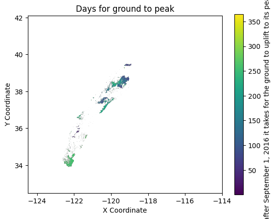

```python
import xarray as xr
import matplotlib.pyplot as plt

# Load the .grd file
insar = xr.open_dataset("../InSAR/phase_2017_filt2_9cm.grd", engine="netcdf4")
print(insar)

print(insar["z"].shape)

print(insar["x"].shape)
print(insar["y"].shape)

days_for_ground_to_peak = insar["z"]

# Convert the data to a numpy array
days_for_ground_to_peak = days_for_ground_to_peak.values

plt.imshow(days_for_ground_to_peak, extent=[insar["x"].min(), insar["x"].max(), insar["y"].min(), insar["y"].max()])
plt.colorbar(label="Days after September 1, 2016 it takes for the ground to uplift to its peak height")
plt.title("Days for ground to peak")
plt.xlabel("X Coordinate")
plt.ylabel("Y Coordinate")
```

## AEM

> I’m not sure how or where the AEM data is stored as I haven’t had the chance to look into it in depth, but there is a PPT called “CV_AEM_InSAR.pptx” with some figures of the previous postdoc Wes combined these datasets. If there is too much AEM data to work with, we can start with just what’s available in the Visalia region (longitude: -119.8 to -119.1; latitude: 36.0 to 36.7).

Okay, let's look at the surverys.

[figure not shown]

It looks like survey 4 is what Silvia wants. We can download that data from [here](https://data.cnra.ca.gov/dataset/aem). Let's unzip it and see what there is. Oh wow, just for survey 4 the data zip is 6 GiB. That is pretty large!

Some open questions that I want to answer:

1. Is there any data that is already interpolated? Or is the data just directly from the flight paths.
2. We are intersted in resistivity. That comes from an inversion of the raw AEM data. That has already occured.
3. What is CVHM texture? That seems to maybe be interpolated data? Ahh no CVHM just refers to a model. I will ignore that for the moment.

I think my first goal is to display the data from the whole region as a 3D map. Initially I think that will occur as un-interpolated data via flight paths. Once I am there I may email Silvia and pause for the moment.

I tried to download `Survey Area 4 - AEM Data` but ran into an issue with the zipped file. This is the zipped file I [downloaded](https://data.cnra.ca.gov/dataset/aem/resource/c282ee67-de22-45df-9293-b6478c9d3b24).